# Customer Traffic Estimation using GWR

Shaina Nair

2024-11-23

## Step 1 : Load and Prepare the data

```r
# Define the file path to CSV in the Downloads folder
file_path <- "~/Downloads/Merged_Traffic_and_Store_Data_with_Coordinates.csv"

# Load the dataset
traffic_data <- read.csv(file_path)

# Display the first few rows to confirm successful loading
head(traffic_data)
```

```
##   X                 StoreID Estimated_Traffic Mean_Utility Latitude Longitude
## 1 0 ATTITUDE DANCE BOUTIQUE          102.7483     103.5654 30.62850 -96.32050
## 2 1       BEA'S ALTERATIONS          101.6910     101.6211 30.61700 -96.30200
## 3 2     BRAZOS BRIM HAT BAR          102.2954     102.4008 30.60150 -96.31470
## 4 3            GRASS STAINS          105.6120     106.8239 30.62150 -96.33900
## 5 4          HULLABALOO AVE          106.7865     106.8239 30.61230 -96.34120
## 6 5          HULLABALOO AVE          106.7865     106.8239 30.60533 -96.33812
```

#### FYI :

##### Estimated_Traffic: Represents the predicted number of customers expected to visit a store and quantitative measure of the demand a store might experience, derived from factors like attractiveness, accessibility, and customer behavior. Tells us how many customers are likely to visit this store

##### Mean_Utility: Reflects the calculated attractiveness of a store based on socio-demographic characteristics, which is a qualitative measure of how well a store matches the demographic profile of its surrounding population (income, education, population density). It tell us how well this store aligns with the preferences and demographics of the target population

## Step 2 : Verifying Spatial Structure

```r
library(sp)

# Ensure Latitude and Longitude are numeric
traffic_data$Latitude <- as.numeric(traffic_data$Latitude)
traffic_data$Longitude <- as.numeric(traffic_data$Longitude)

# Convert traffic_data to SpatialPointsDataFrame
coordinates(traffic_data) <- ~Longitude+Latitude
proj4string(traffic_data) <- CRS("+proj=longlat +datum=WGS84")  # Assign WGS84 CRS

# Check if traffic_data is a spatial object
is_spatial <- class(traffic_data)
print(is_spatial)
```

```
## [1] "SpatialPointsDataFrame"
## attr(,"package")
## [1] "sp"
```

```r
# Check spatial structure
summary(traffic_data)
```

```
## Object of class SpatialPointsDataFrame
## Coordinates:
##                 min       max
## Longitude -96.34648 -96.26082
## Latitude   30.55530  30.65020
## Is projected: FALSE
## proj4string : [+proj=longlat +datum=WGS84 +no_defs]
## Number of points: 142
## Data attributes:
##        X            StoreID          Estimated_Traffic  Mean_Utility
##  Min.   :  0.00   Length:142         Min.   : 96.82    Min.   : 97.11
##  1st Qu.: 35.25   Class :character   1st Qu.:101.23    1st Qu.:102.06
##  Median : 70.50   Mode  :character   Median :102.50    Median :102.63
##  Mean   : 70.50                      Mean   :102.46    Mean   :102.53
##  3rd Qu.:105.75                      3rd Qu.:103.79    3rd Qu.:103.57
##  Max.   :141.00                      Max.   :107.78    Max.   :106.82
```

## Step 3 :Explore and Visualize the Data

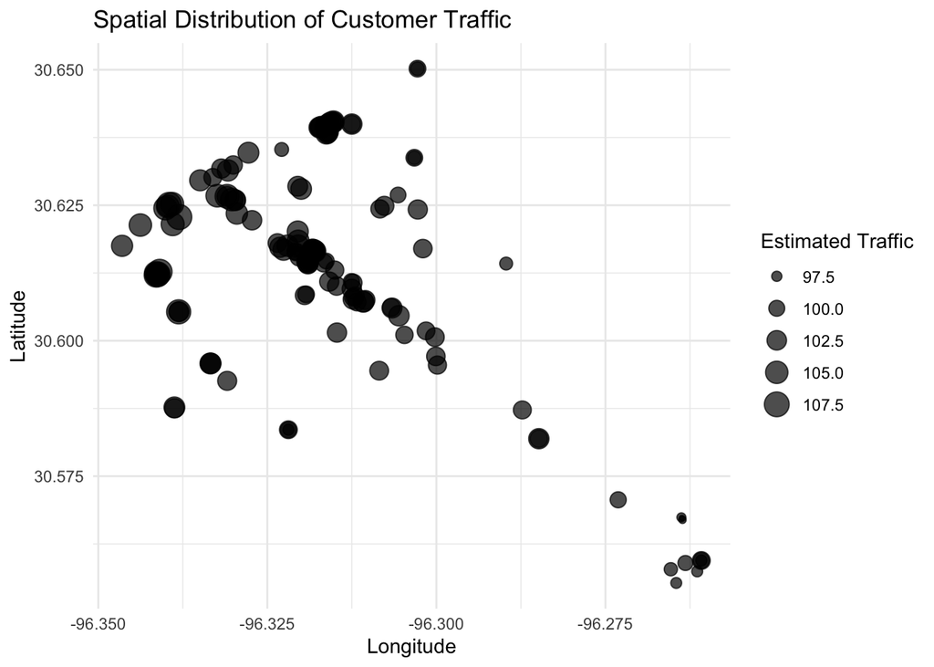

```r
library(ggplot2)

# Convert spatial object to a data frame for ggplot
traffic_df <- as.data.frame(traffic_data)

# Plot spatial distribution of customer traffic
ggplot(data = traffic_df, aes(x = Longitude, y = Latitude, size = Estimated_Traffic)) +
  geom_point(alpha = 0.7) +
  theme_minimal() +
  labs(title = "Spatial Distribution of Customer Traffic",
       x = "Longitude", y = "Latitude", size = "Estimated Traffic")
```

## Step 4 : Fit a Global regression Model (Baseline)

Before running GWR, we fit a global regression model to understand the overall relationship between the independent variables and Estimated_Traffic.

```r
# Fit a global regression model
global_model <- lm(Estimated_Traffic ~ Mean_Utility, data = traffic_df)

# Display the summary of the global regression model
summary(global_model)
```

```
##
## Call:
## lm(formula = Estimated_Traffic ~ Mean_Utility, data = traffic_df)
##
## Residuals:
##      Min       1Q   Median       3Q      Max
## -2.02280 -0.66584 -0.01492  0.65933  1.88152
##
## Coefficients:
##              Estimate Std. Error t value Pr(>|t|)
## (Intercept)   5.60660    3.50096   1.601    0.112
## Mean_Utility  0.94460    0.03414  27.671   <2e-16 ***
## ---
## Signif. codes:  0 '***' 0.001 '**' 0.01 '*' 0.05 '.' 0.1 ' ' 1
##
## Residual standard error: 0.8807 on 140 degrees of freedom
## Multiple R-squared:  0.8454, Adjusted R-squared:  0.8443
## F-statistic: 765.7 on 1 and 140 DF,  p-value: < 2.2e-16
```